# Peer Assignment 1

## This is the first section of the assignment

```r
library(dplyr)
# Read the dataset, and transform appropriately for the purpose of this assignment.

activity.data<-read.csv("activity.csv")
activity.data$date<-as.Date(activity.data$date,"%Y-%m-%d")
activity.data$interval<-as.factor(activity.data$interval)

# Now for the first part of the assignment, with ignoring the "NAs", clean the dataset
clean.data<-activity.data[complete.cases(activity.data[,1]),]

#Summarize the Total Steps, and do a quick dump of the rows to check sanity of the results.
total.by.date <- summarise(group_by(clean.data,date),sum(steps))
colnames(total.by.date)<-c("Date", "Total_Steps")
head(total.by.date)
```

```
## Source: local data frame [6 x 2]
##
##         Date Total_Steps
## 1 2012-10-02         126
## 2 2012-10-03       11352
## 3 2012-10-04       12116
## 4 2012-10-05       13294
## 5 2012-10-06       15420
## 6 2012-10-07       11015
```

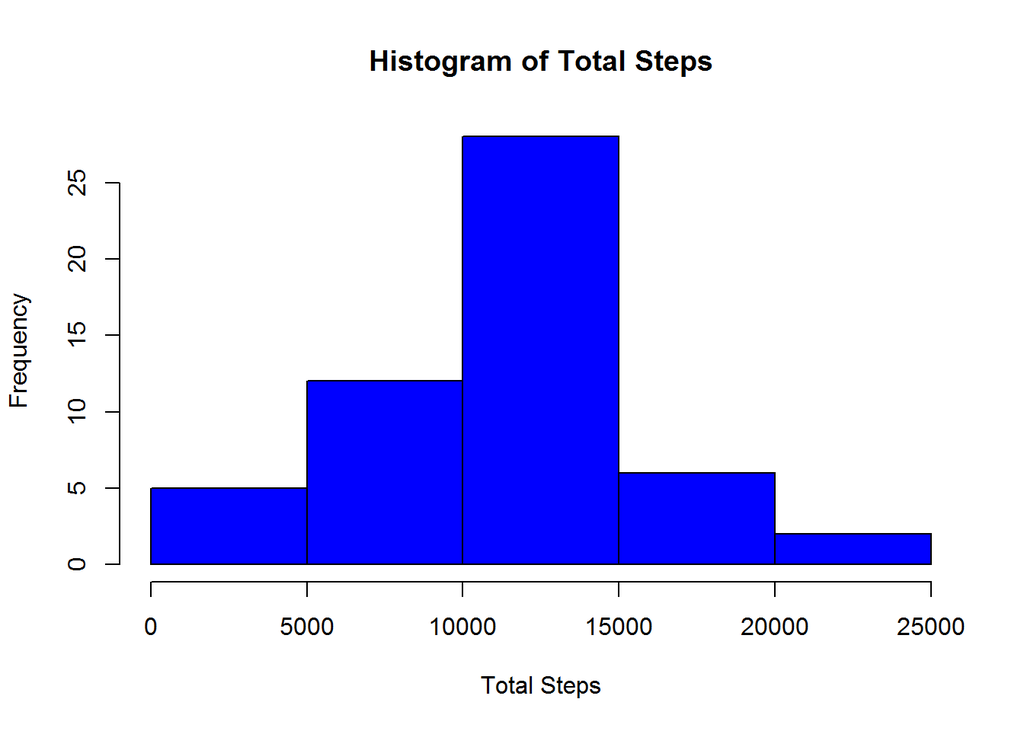

```r
# Plot the Histogram of the Total Steps
hist(total.by.date$Total_Steps,col="blue",xlab="Total Steps", main= "Histogram of Total Steps")
```

```r
# Now Compute the Mean and Median of the clean data set
overall.mean <- round(mean(total.by.date$Total_Steps), digits=2)
overall.median <- round(median(total.by.date$Total_Steps), digits=2)
```

## Second Section of the Assignment - Time Series Plots

```r
#Summarize the Total Steps, now by interval of steps, and do a quick dump of the rows to check sanity of the results.
Mean.by.interval <- summarise(group_by(clean.data,interval),mean(steps))
colnames(Mean.by.interval)<-c("Interval", "Average_Steps")
head(Mean.by.interval)
```

```
## Source: local data frame [6 x 2]
##
##   Interval Average_Steps
## 1        0     1.7169811
## 2        5     0.3396226
## 3       10     0.1320755
## 4       15     0.1509434
## 5       20     0.0754717
## 6       25     2.0943396
```

```r
tail(Mean.by.interval)
```

```
## Source: local data frame [6 x 2]
##
##   Interval Average_Steps
## 1     2330     2.6037736
## 2     2335     4.6981132
## 3     2340     3.3018868
## 4     2345     0.6415094
## 5     2350     0.2264151
## 6     2355     1.0754717
```

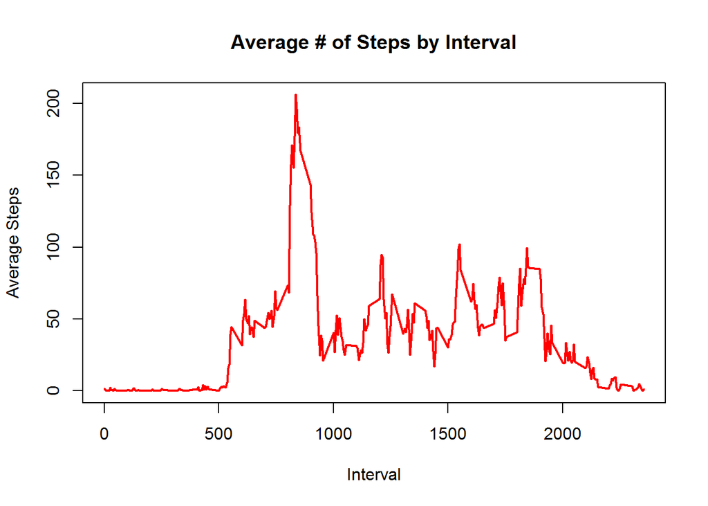

```r
# Now Plot the time series plot
plot(as.numeric(as.character(Mean.by.interval$Interval)), Mean.by.interval$Average_Steps,col="red", lwd=2,type="l", main="Average # of Steps by Interval",xlab="Interval", ylab="Average Steps")
```

```r
Max_Mean<-Mean.by.interval[which.max(Mean.by.interval$Average_Steps),]
```

The Interval with the maximum value is **835** and the corresponding value is **206.1698113**

```r
# Let us check the similar plot for Median : Not required for the assignment, however !!!
Median.by.interval <- summarise(group_by(clean.data,interval),median(steps))
colnames(Median.by.interval)<-c("Interval", "Median_Steps")
head(Median.by.interval)
```

```
## Source: local data frame [6 x 2]
##
##   Interval Median_Steps
## 1        0            0
## 2        5            0
## 3       10            0
## 4       15            0
## 5       20            0
## 6       25            0
```

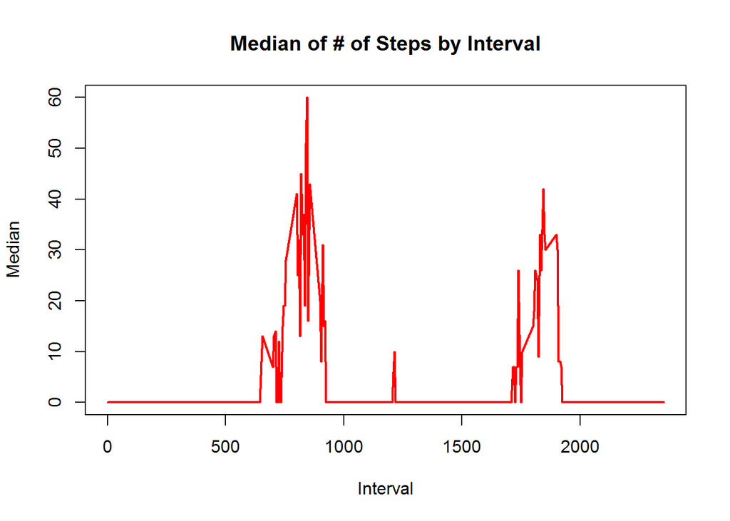

```r
# Now Plot the time series plot
plot(as.numeric(as.character(Median.by.interval$Interval)), Median.by.interval$Median_Steps,col="red", lwd=2,type="l", main="Median of # of Steps by Interval",xlab="Interval", ylab="Median")
```

```r
Max_Median<-Median.by.interval[which.max(Median.by.interval$Median_Steps),]
```

The Interval with the maximum value is **845** and the corresponding value is **60**

## Third Section of the Assignment - Code for inputting the Missing Values - No Graphical output Needed

In this section, the missing values are filled by the median of the corresponding interval. For example if data is missing for an interval = 5, then that value is filled by the median for the interval =5 from all the days.

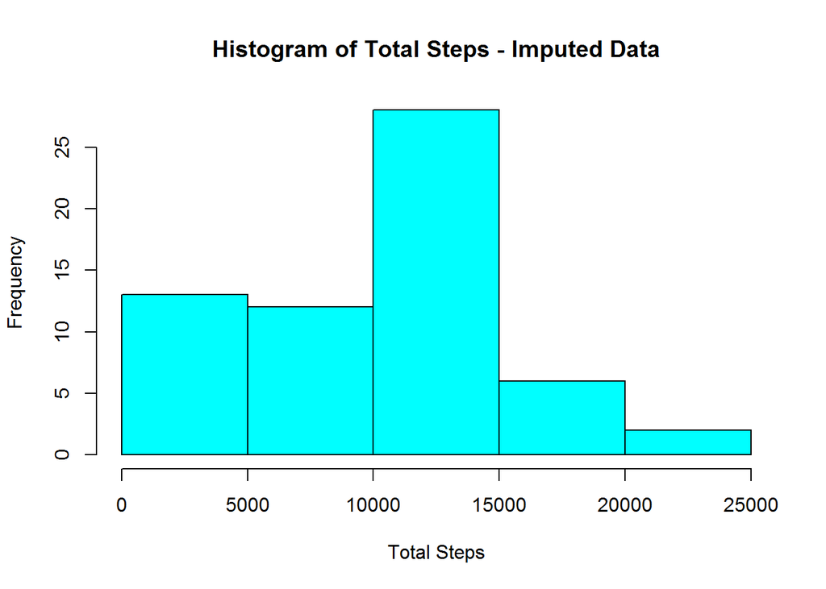

```r
# Use the Median of each interval to fill the data of steps for the missing value across the board.
#Median.by.interval <- summarise(group_by(clean.data,interval),median(steps))

na.count<- 0
i<- 1
while ( i <= nrow(activity.data)) {
      if(is.na(activity.data[i,1])){
# Now for all the na values of steps, replace with the median of the corresponding interval.
            na.count<- na.count + 1
            activity.interval<-as.integer(activity.data[i,3])
            j<- 1
            while( j <= nrow(Median.by.interval)){
                  median.interval<- as.integer(Median.by.interval[j,1])
                  if(activity.interval == median.interval){
                        activity.data[i,1]<-Median.by.interval[j,2]
                  }
                  j<- j + 1
            }

      }
      i <- i + 1

}


#Summarize the Total Steps, and do a quick dump of the rows to check sanity of the results.
Full.by.date <- summarise(group_by(activity.data,date),sum(steps))
colnames(Full.by.date)<-c("Date", "Total_Steps")

# Plot the Histogram of the Total Steps
hist(Full.by.date$Total_Steps,col="cyan",xlab="Total Steps", main= "Histogram of Total Steps - Imputed Data")
```

```r
# Now Compute the Mean and Median of the clean data set
Full.mean <- round(mean(Full.by.date$Total_Steps), digits=2)
Full.median <- round(median(Full.by.date$Total_Steps),digits=2)
```

## Fourth Section of the Assignment - Adding weekdays and plotting the results for weekdays and weekends

```r
# Create a vector of Weekdays
day.vec<-factor(weekdays(activity.data$date,abbreviate=TRUE)%in% c("Sat","Sun"),levels=c(TRUE,FALSE),labels=c("Weekend","Weekday"))
activity.data[,"Day"]<-day.vec
#head(activity.data)
# Now that a factor of the weekday and weekend is created
#Summarize the Total Steps, now by interval of steps, and do a quick dump of the rows to check sanity of the results.
Mean.by.Day <- summarise(group_by(activity.data,interval,Day),mean(steps))
colnames(Mean.by.Day)<-c("Interval","Day", "Average_Steps")
head(Mean.by.Day)
```

```
## Source: local data frame [6 x 3]
##
##   Interval     Day Average_Steps
## 1        0 Weekend     0.0000000
## 2        0 Weekday     2.0222222
## 3        5 Weekend     0.0000000
## 4        5 Weekday     0.4000000
## 5       10 Weekend     0.0000000
## 6       10 Weekday     0.1555556
```

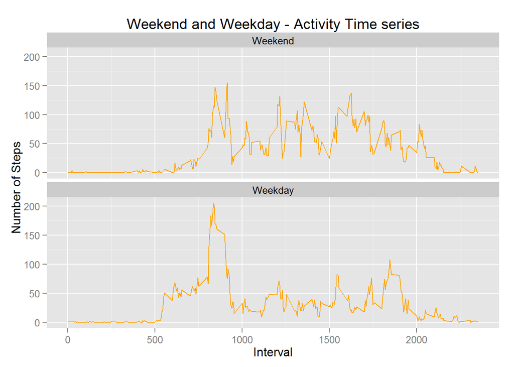

```r
# Now Plot the time series plot
library(ggplot2)
ggplot(Mean.by.Day, aes(x=as.numeric(as.character(Interval)),y=Average_Steps))+
      geom_line(color="orange") +
      facet_wrap(~Day,nrow=2,ncol=1)+
      labs(x="Interval",y="Number of Steps")+
      ggtitle("Weekend and Weekday - Activity Time series")
```

From the above plot, the weekend and weekday activities are different.